# Zotero group PAND

Published

18 November 2026

Zotero data of 16 October 2026 · IPBES Literature Report 0.7.0 · [source code on GitHub](https://github.com/IPBES-Data/IPBES.LiteratureReport)

This report shows the state of the Zotero group **PAND** ([open the group in Zotero](https://www.zotero.org/groups/2499181)). It gives an overview of the literature in the group, and lists the items which should be corrected.

Each item in the lists can be opened in the Zotero **web** library or in the Zotero **app** on your computer, so that it can be corrected directly. Corrected items disappear from the lists the next time the report is updated. Some checks compare the items with [OpenAlex](https://openalex.org), an open catalogue of scholarly publications.

## Summary

| Status | Check | Items |
| --- | --- | --- |
| ● Please fix | Retracted publications | 1 |
| ● Please fix | DOI points to a different publication | 10 |
| ● Please fix | Items which are in the group more than once | 1 |
| ● OK | DOI field with an invalid DOI | 0 |
| ● Please fix | DOI which does not exist | 1 |
| ● Please fix | DOI field with a link or prefix instead of the DOI | 35 |
| ● Please check | ISSN not in the standard form | 43 |
| ● Please check | DOI in the wrong field | 12 |
| ● Please check | DOI not found in OpenAlex | 1 |
| ● Please check | Missing or unusual publication year | 16 |
| ● Please check | Empty journal, volume, issue or pages, found in OpenAlex | 60 |
| ● Please check | Language not given as a language code | 26 |
| ● OK | Language differs from OpenAlex | 0 |
| ● For information | No language | 559 |
| ● Please check | Items without DOI, ISBN, ISSN or URL | 142 |
| ● Please check | Items without DOI, for which a DOI was found | 77 |
| ● OK | OpenAlex ID in Extra not valid | 0 |
| ● For information | Items without their OpenAlex ID in Extra | 516 |
| ● OK | Items without tags | 0 |

**Please fix**: these items contain errors. **Please check**: these items may need a correction. **For information**: no action needed unless the group uses this, e.g. tags.

## Items to fix

The lists are sorted by importance. Use the search field above a list to find an item. **web** opens the item in the Zotero web library, **app** in the Zotero app.

### Retracted publications

These publications have been retracted. Check whether they should still be cited, and mark or remove them in Zotero.

| Open in Zotero | Title | DOI |
| --- | --- | --- |
| <a href="https://www.zotero.org/groups/2499181/items/A7GZW22G" target="_blank">web</a> &middot; <a href="zotero://select/groups/2499181/items/A7GZW22G">app</a> | RETRACTED ARTICLE: Origin and cross-species transmission of bat coronaviruses in China | <a href="https://doi.org/10.1038/s41467-020-17687-3" target="_blank">10.1038/s41467-020-17687-3</a> |

### DOI points to a different publication

The DOI of these items leads to a publication with a different title or year. Usually the DOI is wrong: open the DOI to see where it leads, and correct it in Zotero. If the titles match and only the year differs, the DOI is probably right and the date in Zotero wrong (unless it is a reprint or another edition): correct the date instead. Differences of one year (e.g. published online before print) are not listed.

If the DOI is right although title or year differ (e.g. a book chapter with the DOI of the whole book, or a wrong year in OpenAlex), add the line `DOI checked: correct` to Extra: the item is then no longer listed (the Zotero plugin offers this as “Keep as it is”).

| Open in Zotero | Title in Zotero | Year in Zotero | The DOI leads to | Its year | DOI |
| --- | --- | --- | --- | --- | --- |
| <a href="https://www.zotero.org/groups/2499181/items/UFREHS9E" target="_blank">web</a> &middot; <a href="zotero://select/groups/2499181/items/UFREHS9E">app</a> | Hunting of mammal species in protected areas of the southern Bahian Atlantic Forest, Brazil | 2019 | Hunting of mammal species in protected areas of the southern Bahian Atlantic Forest, Brazil | 2017 | <a href="https://doi.org/10.1017/s0030605317001247" target="_blank">10.1017/s0030605317001247</a> |
| <a href="https://www.zotero.org/groups/2499181/items/RTB7WGNL" target="_blank">web</a> &middot; <a href="zotero://select/groups/2499181/items/RTB7WGNL">app</a> | Invasion of bluetongue and other orbivirus infections into Europe: the role of biological and climatic processes | 2008 | Las invasiones de lengua azul y otras infecciones por orbivirus en Europa: papel de los procesos biológicos y climáticos | 2008 | <a href="https://doi.org/10.20506/rst.27.2.1801" target="_blank">10.20506/rst.27.2.1801</a> |
| <a href="https://www.zotero.org/groups/2499181/items/W645U9FS" target="_blank">web</a> &middot; <a href="zotero://select/groups/2499181/items/W645U9FS">app</a> | Managing the endogenous risk of disease outbreaks | 2015 | Managing the endogenous risk of disease outbreaks with non-constant background risk | 2014 | <a href="https://doi.org/10.1016/j.jedc.2014.09.014" target="_blank">10.1016/j.jedc.2014.09.014</a> |
| <a href="https://www.zotero.org/groups/2499181/items/FEGR2HUC" target="_blank">web</a> &middot; <a href="zotero://select/groups/2499181/items/FEGR2HUC">app</a> | Subsistence, substitutability and sustainability in consumption | 2017 | Subsistence and Substitutability in Consumer Preferences | 2013 | <a href="https://doi.org/10.1007/s10640-015-9976-z" target="_blank">10.1007/s10640-015-9976-z</a> |
| <a href="https://www.zotero.org/groups/2499181/items/QRNP2VJD" target="_blank">web</a> &middot; <a href="zotero://select/groups/2499181/items/QRNP2VJD">app</a> | Public Health Implications of Changing Rodent Importation Patterns - United States, 1999-2013 | 2017 | Public Health Implications of Changing Rodent Importation Patterns - United States, 1999-2013 | 2015 | <a href="https://doi.org/10.1111/tbed.12396" target="_blank">10.1111/tbed.12396</a> |
| <a href="https://www.zotero.org/groups/2499181/items/MVJ7XKU4" target="_blank">web</a> &middot; <a href="zotero://select/groups/2499181/items/MVJ7XKU4">app</a> | Predicting Pathogen Introduction: West Nile Virus Spread to Galápagos: Predicting West Nile Virus Spread | 2006 | Predicting Pathogen Introduction: West Nile Virus Spread to Galápagos | 2006 | <a href="https://doi.org/10.1111/j.1523-1739.2006.00423.x" target="_blank">10.1111/j.1523-1739.2006.00423.x</a> |
| <a href="https://www.zotero.org/groups/2499181/items/LFQ2IJVT" target="_blank">web</a> &middot; <a href="zotero://select/groups/2499181/items/LFQ2IJVT">app</a> | Jumping back and forth: anthropozoonotic and zoonotic transmission of SARS-CoV-2 on mink farms | 2020 | Transmission of SARS-CoV-2 on mink farms between humans and mink and back to humans | 2020 | <a href="https://doi.org/10.1126/science.abe5901" target="_blank">10.1126/science.abe5901</a> |
| <a href="https://www.zotero.org/groups/2499181/items/A7GZW22G" target="_blank">web</a> &middot; <a href="zotero://select/groups/2499181/items/A7GZW22G">app</a> | Origin and cross-species transmission of bat coronaviruses in China | 2020 | RETRACTED ARTICLE: Origin and cross-species transmission of bat coronaviruses in China | 2020 | <a href="https://doi.org/10.1038/s41467-020-17687-3" target="_blank">10.1038/s41467-020-17687-3</a> |
| <a href="https://www.zotero.org/groups/2499181/items/NKU5WJUD" target="_blank">web</a> &middot; <a href="zotero://select/groups/2499181/items/NKU5WJUD">app</a> | Climate change will drive novel cross-species viral transmission | 2020 | Climate change increases cross-species viral transmission risk | 2022 | <a href="https://doi.org/10.1038/s41586-022-04788-w" target="_blank">10.1038/s41586-022-04788-w</a> |
| <a href="https://www.zotero.org/groups/2499181/items/W6RRHCH2" target="_blank">web</a> &middot; <a href="zotero://select/groups/2499181/items/W6RRHCH2">app</a> | Accessibility and allocation of public parks and gardens during COVID-19 social distancing in England and Wales | 2020 | Accessibility and allocation of public parks and gardens in England and Wales: A COVID-19 social distancing perspective | 2020 | <a href="https://doi.org/10.1371/journal.pone.0241102" target="_blank">10.1371/journal.pone.0241102</a> |

### Items which are in the group more than once

These items are in the group more than once, with the same DOI, or with the same title, year and first author. Keep one copy and merge or delete the others, e.g. with *Duplicate Items* in the Zotero app.

[output not shown]

### DOI field with an invalid DOI

The DOI field of these items contains something which is not a valid DOI. Correct or remove it.

**✔ Nothing to fix.**

### DOI which does not exist

The DOI of these items does not exist at doi.org: usually a typo, a shortened DOI, or a DOI with extra characters at the end. Where the DOI without these characters exists, it is given as suggestion. Otherwise find the right DOI, or remove it (then the search by title in OpenAlex can offer one).

| Open in Zotero | Title | Content of the DOI field | Suggestion |
| --- | --- | --- | --- |
| <a href="https://www.zotero.org/groups/2499181/items/T9NAQLV9" target="_blank">web</a> &middot; <a href="zotero://select/groups/2499181/items/T9NAQLV9">app</a> | Middle East respiratory syndrome coronavirus quasi-species that include homologues of human isolates revealed through whole genome analysis and virus cultured from dromedary camels in Saudi Arabia | 10.1128/mBio.01146-1429 |  |

### DOI field with a link or prefix instead of the DOI

The DOI field of these items contains the DOI as a link (`https://doi.org/…`) or with a prefix (`DOI …`). Citation styles add the link themselves, so it would appear twice. Replace it with the DOI only.

| Open in Zotero | Title | Content of the DOI field | DOI |
| --- | --- | --- | --- |
| <a href="https://www.zotero.org/groups/2499181/items/CQUFDDMI" target="_blank">web</a> &middot; <a href="zotero://select/groups/2499181/items/CQUFDDMI">app</a> | Wildlife laundering through breeding farms: Illegal harvest, population declines and a means of regulating the trade of green pythons (Morelia viridis) from Indonesia | https://doi.org/10.1016/j.biocon.2011.10.002 | <a href="https://doi.org/10.1016/j.biocon.2011.10.002" target="_blank">10.1016/j.biocon.2011.10.002</a> |
| <a href="https://www.zotero.org/groups/2499181/items/5WGNCD4N" target="_blank">web</a> &middot; <a href="zotero://select/groups/2499181/items/5WGNCD4N">app</a> | North Africa as a source for European eel following the 2010 EU CITES eel trade ban | https://doi.org/10.1016/j.marpol.2017.06.036 | <a href="https://doi.org/10.1016/j.marpol.2017.06.036" target="_blank">10.1016/j.marpol.2017.06.036</a> |
| <a href="https://www.zotero.org/groups/2499181/items/W7C34G7L" target="_blank">web</a> &middot; <a href="zotero://select/groups/2499181/items/W7C34G7L">app</a> | Under what circumstances can wildlife farming benefit species conservation? | https://doi.org/10.1016/j.gecco.2016.03.007 | <a href="https://doi.org/10.1016/j.gecco.2016.03.007" target="_blank">10.1016/j.gecco.2016.03.007</a> |
| <a href="https://www.zotero.org/groups/2499181/items/AA4H2YRW" target="_blank">web</a> &middot; <a href="zotero://select/groups/2499181/items/AA4H2YRW">app</a> | CITES-listings, EU eel trade bans and the increase of export of tropical eels out of Indonesia | https://doi.org/10.1016/j.marpol.2015.04.006 | <a href="https://doi.org/10.1016/j.marpol.2015.04.006" target="_blank">10.1016/j.marpol.2015.04.006</a> |
| <a href="https://www.zotero.org/groups/2499181/items/WCE5B8XK" target="_blank">web</a> &middot; <a href="zotero://select/groups/2499181/items/WCE5B8XK">app</a> | Dynamics of the global trade in live reptiles: Shifting trends in production and consequences for sustainability | https://doi.org/10.1016/j.biocon.2014.12.019 | <a href="https://doi.org/10.1016/j.biocon.2014.12.019" target="_blank">10.1016/j.biocon.2014.12.019</a> |
| <a href="https://www.zotero.org/groups/2499181/items/W332D6Q2" target="_blank">web</a> &middot; <a href="zotero://select/groups/2499181/items/W332D6Q2">app</a> | Wildlife sinks: Quantifying the impact of illegal bird trade in street markets in Brazil | https://doi.org/10.1016/j.biocon.2012.02.009 | <a href="https://doi.org/10.1016/j.biocon.2012.02.009" target="_blank">10.1016/j.biocon.2012.02.009</a> |
| <a href="https://www.zotero.org/groups/2499181/items/J5VSEZQD" target="_blank">web</a> &middot; <a href="zotero://select/groups/2499181/items/J5VSEZQD">app</a> | Horizon Scan of the Belt and Road Initiative | https://doi.org/10.1016/j.tree.2020.02.005 | <a href="https://doi.org/10.1016/j.tree.2020.02.005" target="_blank">10.1016/j.tree.2020.02.005</a> |
| <a href="https://www.zotero.org/groups/2499181/items/7NY9SWAQ" target="_blank">web</a> &middot; <a href="zotero://select/groups/2499181/items/7NY9SWAQ">app</a> | Assessing the changes in international trade of marine fishes under CITES regulations – A case study of seahorses | https://doi.org/10.1016/j.marpol.2017.10.031 | <a href="https://doi.org/10.1016/j.marpol.2017.10.031" target="_blank">10.1016/j.marpol.2017.10.031</a> |
| <a href="https://www.zotero.org/groups/2499181/items/VPKTCZE9" target="_blank">web</a> &middot; <a href="zotero://select/groups/2499181/items/VPKTCZE9">app</a> | The Berlin principles on one health – Bridging global health and conservation | https://doi.org/10.1016/j.scitotenv.2020.142919 | <a href="https://doi.org/10.1016/j.scitotenv.2020.142919" target="_blank">10.1016/j.scitotenv.2020.142919</a> |
| <a href="https://www.zotero.org/groups/2499181/items/Z2GCC8IX" target="_blank">web</a> &middot; <a href="zotero://select/groups/2499181/items/Z2GCC8IX">app</a> | Global wildlife trade permeates the Tree of Life | https://doi.org/10.1016/j.biocon.2020.108503 | <a href="https://doi.org/10.1016/j.biocon.2020.108503" target="_blank">10.1016/j.biocon.2020.108503</a> |

[output cut: 25 more lines]

### ISSN not in the standard form

The ISSN field of these items is not in the standard form `1234-567X` (several separated by “,”), or contains something which is not a valid ISSN, e.g. an ISBN.

| Open in Zotero | Title | Content of the ISSN field | Standard form | Not a valid ISSN |
| --- | --- | --- | --- | --- |
| <a href="https://www.zotero.org/groups/2499181/items/CSC9FGYN" target="_blank">web</a> &middot; <a href="zotero://select/groups/2499181/items/CSC9FGYN">app</a> | Livelihood alternatives for the unsustainable use of bushmeat. Report prepared for the CBD Bushmeat Liaison Group. Technical Series No. 60, Montreal, SCBD, 46 pages. | 9292253883 | NA | 9292253883 |
| <a href="https://www.zotero.org/groups/2499181/items/35LDBXIW" target="_blank">web</a> &middot; <a href="zotero://select/groups/2499181/items/35LDBXIW">app</a> | EU Trade Policy and the Wildlife Trade | 9284603854 | NA | 9284603854 |
| <a href="https://www.zotero.org/groups/2499181/items/324DAV7H" target="_blank">web</a> &middot; <a href="zotero://select/groups/2499181/items/324DAV7H">app</a> | New products and industries from biodiversity | 1559632283 | NA | 1559632283 |
| <a href="https://www.zotero.org/groups/2499181/items/7ABJ9DAJ" target="_blank">web</a> &middot; <a href="zotero://select/groups/2499181/items/7ABJ9DAJ">app</a> | Biodiversity loss and the ecology of infectious disease | 25425196 | 2542-5196 | NA |
| <a href="https://www.zotero.org/groups/2499181/items/NCNEV5AJ" target="_blank">web</a> &middot; <a href="zotero://select/groups/2499181/items/NCNEV5AJ">app</a> | Prediction and prevention of the next pandemic zoonosis | 01406736 | 0140-6736 | NA |
| <a href="https://www.zotero.org/groups/2499181/items/Z7PXXRJZ" target="_blank">web</a> &middot; <a href="zotero://select/groups/2499181/items/Z7PXXRJZ">app</a> | Tick-borne encephalitis virus in cows and unpasteurized cow milk from Norway | 18631959 | 1863-1959 | NA |
| <a href="https://www.zotero.org/groups/2499181/items/ACV8Z7IJ" target="_blank">web</a> &middot; <a href="zotero://select/groups/2499181/items/ACV8Z7IJ">app</a> | ProMED global monitoring of emerging diseases: design for a demonstration program | 01688510 | 0168-8510 | NA |
| <a href="https://www.zotero.org/groups/2499181/items/QRNP2VJD" target="_blank">web</a> &middot; <a href="zotero://select/groups/2499181/items/QRNP2VJD">app</a> | Public Health Implications of Changing Rodent Importation Patterns - United States, 1999-2013 | 18651674 | 1865-1674 | NA |
| <a href="https://www.zotero.org/groups/2499181/items/MVJ7XKU4" target="_blank">web</a> &middot; <a href="zotero://select/groups/2499181/items/MVJ7XKU4">app</a> | Predicting Pathogen Introduction: West Nile Virus Spread to Galápagos: Predicting West Nile Virus Spread | 08888892 | 0888-8892 | NA |
| <a href="https://www.zotero.org/groups/2499181/items/FCPST23E" target="_blank">web</a> &middot; <a href="zotero://select/groups/2499181/items/FCPST23E">app</a> | What can we predict about viral evolution and emergence? | 18796257 | 1879-6257 | NA |

[output cut: 33 more lines]

### DOI in the wrong field

These items have no DOI in the DOI field, but a DOI in the URL or Extra field. Copy the DOI into the DOI field.

| Open in Zotero | Title | DOI in URL | DOI in Extra |
| --- | --- | --- | --- |
| <a href="https://www.zotero.org/groups/2499181/items/8L4MCXZ7" target="_blank">web</a> &middot; <a href="zotero://select/groups/2499181/items/8L4MCXZ7">app</a> | Healthy Wetlands, Healthy People: Mosquito Borne Disease | <a href="https://doi.org/10.1007/978-94-017-9609-5_6" target="_blank">10.1007/978-94-017-9609-5_6</a> | <a href="https://doi.org/10.1007/978-94-017-9609-5_6" target="_blank">10.1007/978-94-017-9609-5_6</a> |
| <a href="https://www.zotero.org/groups/2499181/items/MCDKH3HK" target="_blank">web</a> &middot; <a href="zotero://select/groups/2499181/items/MCDKH3HK">app</a> | Emerging Viral Zoonoses from Wildlife Associated with Animal-Based Food Systems: Risks and Opportunities | <a href="https://doi.org/10.1007/978-3-319-24442-6_2" target="_blank">10.1007/978-3-319-24442-6_2</a> | <a href="https://doi.org/10.1007/978-3-319-24442-6_2" target="_blank">10.1007/978-3-319-24442-6_2</a> |
| <a href="https://www.zotero.org/groups/2499181/items/HQG8VMZA" target="_blank">web</a> &middot; <a href="zotero://select/groups/2499181/items/HQG8VMZA">app</a> | The Inclusive Cost of Pandemic Influenza Risk |  | <a href="https://doi.org/10.3386/w22137" target="_blank">10.3386/w22137</a> |
| <a href="https://www.zotero.org/groups/2499181/items/DCN7WF6A" target="_blank">web</a> &middot; <a href="zotero://select/groups/2499181/items/DCN7WF6A">app</a> | The ‘Anthropocene’ (2002) | <a href="https://doi.org/10.1007/978-3-030-82202-6_4" target="_blank">10.1007/978-3-030-82202-6_4</a> | <a href="https://doi.org/10.1007/978-3-030-82202-6_4" target="_blank">10.1007/978-3-030-82202-6_4</a> |
| <a href="https://www.zotero.org/groups/2499181/items/32YRPJEY" target="_blank">web</a> &middot; <a href="zotero://select/groups/2499181/items/32YRPJEY">app</a> | Zoonoses |  | <a href="https://doi.org/10.1016/b978-012373944-5.00213-3" target="_blank">10.1016/b978-012373944-5.00213-3</a> |
| <a href="https://www.zotero.org/groups/2499181/items/ET2ZVRAW" target="_blank">web</a> &middot; <a href="zotero://select/groups/2499181/items/ET2ZVRAW">app</a> | Chapter 2.1 Status and Trends –Drivers of Change |  | <a href="https://doi.org/10.5281/zenodo.3831881" target="_blank">10.5281/zenodo.3831881</a> |
| <a href="https://www.zotero.org/groups/2499181/items/FPMXZQI5" target="_blank">web</a> &middot; <a href="zotero://select/groups/2499181/items/FPMXZQI5">app</a> | A One Health Approach to Wildlife and Food Safety | <a href="https://doi.org/10.1007/978-3-319-24442-6_11" target="_blank">10.1007/978-3-319-24442-6_11</a> | <a href="https://doi.org/10.1007/978-3-319-24442-6_11" target="_blank">10.1007/978-3-319-24442-6_11</a> |
| <a href="https://www.zotero.org/groups/2499181/items/GYWZ5QIB" target="_blank">web</a> &middot; <a href="zotero://select/groups/2499181/items/GYWZ5QIB">app</a> | Climate Change and Human Health Scenario in South and Southeast Asia |  | <a href="https://doi.org/10.1007/978-3-319-23684-1" target="_blank">10.1007/978-3-319-23684-1</a> |
| <a href="https://www.zotero.org/groups/2499181/items/A6RYYHH8" target="_blank">web</a> &middot; <a href="zotero://select/groups/2499181/items/A6RYYHH8">app</a> | Bats, Civets and the Emergence of SARS | <a href="https://doi.org/10.1007/978-3-540-70962-6_13" target="_blank">10.1007/978-3-540-70962-6_13</a> | <a href="https://doi.org/10.1007/978-3-540-70962-6_13" target="_blank">10.1007/978-3-540-70962-6_13</a> |
| <a href="https://www.zotero.org/groups/2499181/items/29M3QGFN" target="_blank">web</a> &middot; <a href="zotero://select/groups/2499181/items/29M3QGFN">app</a> | Sporadic influenza A virus infections of miscellaneous mammal species | <a href="https://doi.org/10.1002/9781118924341.ch23" target="_blank">10.1002/9781118924341.ch23</a> | <a href="https://doi.org/10.1002/9781118924341.ch23" target="_blank">10.1002/9781118924341.ch23</a> |

[output cut: 2 more lines]

### DOI not found in OpenAlex

These DOIs exist, but were not found in OpenAlex (DOIs which do not exist are listed above). If the DOI leads to the right publication, the publication is simply not (yet) in OpenAlex and nothing needs to be done.

| Open in Zotero | Title | DOI |
| --- | --- | --- |
| <a href="https://www.zotero.org/groups/2499181/items/YFV5DLMK" target="_blank">web</a> &middot; <a href="zotero://select/groups/2499181/items/YFV5DLMK">app</a> | Post COVID-19: a solution scan of options for preventing future zoonotic epidemics | <a href="https://doi.org/10.17605/osf.io/5jx3g" target="_blank">10.17605/osf.io/5jx3g</a> |

### Missing or unusual publication year

These items have no date, a date from which no year could be read, or a year in the future. Correct the date in Zotero.

| Open in Zotero | Title | Date | Problem | Date in OpenAlex |
| --- | --- | --- | --- | --- |
| <a href="https://www.zotero.org/groups/2499181/items/EZCQMVGE" target="_blank">web</a> &middot; <a href="zotero://select/groups/2499181/items/EZCQMVGE">app</a> | Zoonoses |  | No date | NA |
| <a href="https://www.zotero.org/groups/2499181/items/TUCA36S2" target="_blank">web</a> &middot; <a href="zotero://select/groups/2499181/items/TUCA36S2">app</a> | wildlife product |  | No date | NA |
| <a href="https://www.zotero.org/groups/2499181/items/THRQ5ABD" target="_blank">web</a> &middot; <a href="zotero://select/groups/2499181/items/THRQ5ABD">app</a> | Ending Poverty |  | No date | NA |
| <a href="https://www.zotero.org/groups/2499181/items/V8UTRPY6" target="_blank">web</a> &middot; <a href="zotero://select/groups/2499181/items/V8UTRPY6">app</a> | CITES glossary |  | No date | NA |
| <a href="https://www.zotero.org/groups/2499181/items/CU42BHJN" target="_blank">web</a> &middot; <a href="zotero://select/groups/2499181/items/CU42BHJN">app</a> | IUCN DEFINITIONS |  | No date | NA |
| <a href="https://www.zotero.org/groups/2499181/items/J2SBFFCX" target="_blank">web</a> &middot; <a href="zotero://select/groups/2499181/items/J2SBFFCX">app</a> | Infectious disease threats: from rebound to resilience | In review | Year not recognised | NA |
| <a href="https://www.zotero.org/groups/2499181/items/KXAEEFP4" target="_blank">web</a> &middot; <a href="zotero://select/groups/2499181/items/KXAEEFP4">app</a> | Snakes and ladders: a review of ball python production in West Africa for the global pet market |  | No date | NA |
| <a href="https://www.zotero.org/groups/2499181/items/6KAJ55P4" target="_blank">web</a> &middot; <a href="zotero://select/groups/2499181/items/6KAJ55P4">app</a> | COVID-19: Protect great apes during human pandemic |  | No date | NA |
| <a href="https://www.zotero.org/groups/2499181/items/5W3XUQD5" target="_blank">web</a> &middot; <a href="zotero://select/groups/2499181/items/5W3XUQD5">app</a> | Understanding the WTO Agreement on Sanitary and Phytosanitary Measures |  | No date | NA |
| <a href="https://www.zotero.org/groups/2499181/items/HAMZEEXQ" target="_blank">web</a> &middot; <a href="zotero://select/groups/2499181/items/HAMZEEXQ">app</a> | Avian Influenza |  | No date | NA |

[output cut: 6 more lines]

### Empty journal, volume, issue or pages, found in OpenAlex

These journal articles have an empty journal, volume, issue or pages field, and OpenAlex has the value for their DOI. Check it with the DOI and fill in the field.

| Open in Zotero | Title | Field | Value in OpenAlex | DOI |
| --- | --- | --- | --- | --- |
| <a href="https://www.zotero.org/groups/2499181/items/3Q92MM99" target="_blank">web</a> &middot; <a href="zotero://select/groups/2499181/items/3Q92MM99">app</a> | A familial cluster of pneumonia associated with the 2019 novel coronavirus indicating person-to-person transmission: a study of a family cluster | Volume | 395 | <a href="https://doi.org/10.1016/s0140-6736(20)30154-9" target="_blank">10.1016/s0140-6736(20)30154-9</a> |
| <a href="https://www.zotero.org/groups/2499181/items/3Q92MM99" target="_blank">web</a> &middot; <a href="zotero://select/groups/2499181/items/3Q92MM99">app</a> | A familial cluster of pneumonia associated with the 2019 novel coronavirus indicating person-to-person transmission: a study of a family cluster | Issue | 10223 | <a href="https://doi.org/10.1016/s0140-6736(20)30154-9" target="_blank">10.1016/s0140-6736(20)30154-9</a> |
| <a href="https://www.zotero.org/groups/2499181/items/3Q92MM99" target="_blank">web</a> &middot; <a href="zotero://select/groups/2499181/items/3Q92MM99">app</a> | A familial cluster of pneumonia associated with the 2019 novel coronavirus indicating person-to-person transmission: a study of a family cluster | Pages | 514-523 | <a href="https://doi.org/10.1016/s0140-6736(20)30154-9" target="_blank">10.1016/s0140-6736(20)30154-9</a> |
| <a href="https://www.zotero.org/groups/2499181/items/VPWDWT5I" target="_blank">web</a> &middot; <a href="zotero://select/groups/2499181/items/VPWDWT5I">app</a> | A pneumonia outbreak associated with a new coronavirus of probable bat origin | Volume | 579 | <a href="https://doi.org/10.1038/s41586-020-2012-7" target="_blank">10.1038/s41586-020-2012-7</a> |
| <a href="https://www.zotero.org/groups/2499181/items/VPWDWT5I" target="_blank">web</a> &middot; <a href="zotero://select/groups/2499181/items/VPWDWT5I">app</a> | A pneumonia outbreak associated with a new coronavirus of probable bat origin | Issue | 7798 | <a href="https://doi.org/10.1038/s41586-020-2012-7" target="_blank">10.1038/s41586-020-2012-7</a> |
| <a href="https://www.zotero.org/groups/2499181/items/VPWDWT5I" target="_blank">web</a> &middot; <a href="zotero://select/groups/2499181/items/VPWDWT5I">app</a> | A pneumonia outbreak associated with a new coronavirus of probable bat origin | Pages | 270-273 | <a href="https://doi.org/10.1038/s41586-020-2012-7" target="_blank">10.1038/s41586-020-2012-7</a> |
| <a href="https://www.zotero.org/groups/2499181/items/THRRQLSZ" target="_blank">web</a> &middot; <a href="zotero://select/groups/2499181/items/THRRQLSZ">app</a> | Bat conservation and zoonotic disease risk: a research agenda to prevent misguided persecution in the aftermath of COVID-19 | Pages | 303-307 | <a href="https://doi.org/10.1111/acv.12636" target="_blank">10.1111/acv.12636</a> |
| <a href="https://www.zotero.org/groups/2499181/items/UC2LWAM8" target="_blank">web</a> &middot; <a href="zotero://select/groups/2499181/items/UC2LWAM8">app</a> | Bats and COVID-19: villains or victims? | Issue | 3 | <a href="https://doi.org/10.1590/1676-0611-bn-2020-1055" target="_blank">10.1590/1676-0611-bn-2020-1055</a> |
| <a href="https://www.zotero.org/groups/2499181/items/ZBPATV5U" target="_blank">web</a> &middot; <a href="zotero://select/groups/2499181/items/ZBPATV5U">app</a> | Bats host major mammalian paramyxoviruses | Issue | 1 | <a href="https://doi.org/10.1038/ncomms1796" target="_blank">10.1038/ncomms1796</a> |
| <a href="https://www.zotero.org/groups/2499181/items/WMUTUPMW" target="_blank">web</a> &middot; <a href="zotero://select/groups/2499181/items/WMUTUPMW">app</a> | Biodiversity, drug discovery, and the future of global health: Introducing the biodiversity to biomedicine consortium, a call to action | Pages | 020304 | <a href="https://doi.org/10.7189/jogh.07.020304" target="_blank">10.7189/jogh.07.020304</a> |

[output cut: 83 more lines]

### Language not given as a language code

The language of these items is not given as a language code (`en`, `fr`, `en-US`), e.g. as `English` or `eng`. Citation styles only recognise the codes. Where the language was recognised, the code is shown; otherwise look up the code in the [ISO 639-1 list](https://en.wikipedia.org/wiki/List_of_ISO_639_language_codes).

| Open in Zotero | Title | Language | Language code |
| --- | --- | --- | --- |
| <a href="https://www.zotero.org/groups/2499181/items/CTJTVFNR" target="_blank">web</a> &middot; <a href="zotero://select/groups/2499181/items/CTJTVFNR">app</a> | One health: the theory and practice of integrated health approaches | eng | en |
| <a href="https://www.zotero.org/groups/2499181/items/EYWXJBBW" target="_blank">web</a> &middot; <a href="zotero://select/groups/2499181/items/EYWXJBBW">app</a> | Brenner's encyclopedia of genetics | eng | en |
| <a href="https://www.zotero.org/groups/2499181/items/I35JTJVU" target="_blank">web</a> &middot; <a href="zotero://select/groups/2499181/items/I35JTJVU">app</a> | Transmissions to mice indicate that 'new variant' CJD is caused by the BSE agent | eng | en |
| <a href="https://www.zotero.org/groups/2499181/items/IERRUNXL" target="_blank">web</a> &middot; <a href="zotero://select/groups/2499181/items/IERRUNXL">app</a> | Rabies in northeastern Europe--the threat from invasive raccoon dogs | eng | en |
| <a href="https://www.zotero.org/groups/2499181/items/KJEX4SBD" target="_blank">web</a> &middot; <a href="zotero://select/groups/2499181/items/KJEX4SBD">app</a> | The impact of community organization on vector-borne pathogens | eng | en |
| <a href="https://www.zotero.org/groups/2499181/items/EA6B4NPF" target="_blank">web</a> &middot; <a href="zotero://select/groups/2499181/items/EA6B4NPF">app</a> | The internet and the global monitoring of emerging diseases: lessons from the first 10 years of ProMED-mail | eng | en |
| <a href="https://www.zotero.org/groups/2499181/items/XIJGFMQX" target="_blank">web</a> &middot; <a href="zotero://select/groups/2499181/items/XIJGFMQX">app</a> | The ecology of infectious disease: effects of host diversity and community composition on Lyme disease risk | eng | en |
| <a href="https://www.zotero.org/groups/2499181/items/A483I8TN" target="_blank">web</a> &middot; <a href="zotero://select/groups/2499181/items/A483I8TN">app</a> | ProMED mail | https://promedmail.org/ | NA |
| <a href="https://www.zotero.org/groups/2499181/items/HXG8ABMU" target="_blank">web</a> &middot; <a href="zotero://select/groups/2499181/items/HXG8ABMU">app</a> | One health: the Hong Kong experience with avian influenza | eng | en |
| <a href="https://www.zotero.org/groups/2499181/items/5KGK3VQZ" target="_blank">web</a> &middot; <a href="zotero://select/groups/2499181/items/5KGK3VQZ">app</a> | New Zealand's experience of the 1918-19 influenza pandemic: a systematic review after 100 years | eng | en |

[output cut: 16 more lines]

### Language differs from OpenAlex

The language of these items differs from the language of their DOI in OpenAlex. OpenAlex detects the language from the title and abstract, and many publications in other languages have an English abstract: the language in Zotero is often right. Check the publication and correct the language if needed; if it is right, add the line `Language checked: correct` to Extra, and the item is no longer listed.

**✔ Nothing to fix.**

### No language

These items have no language. Where possible, a language is proposed: from OpenAlex for items with a DOI, or else detected from the abstract (with the Compact Language Detector 2, a statistical method, not AI). Both are the language of the title or abstract, which may differ from the language of the publication.

| Open in Zotero | Title | Proposed language | From | DOI |
| --- | --- | --- | --- | --- |
| <a href="https://www.zotero.org/groups/2499181/items/FEXSK6VJ" target="_blank">web</a> &middot; <a href="zotero://select/groups/2499181/items/FEXSK6VJ">app</a> | The IUCN Red List of Threatened Species. Version 2020-1 | NA | NA |  |
| <a href="https://www.zotero.org/groups/2499181/items/V6PBDIS4" target="_blank">web</a> &middot; <a href="zotero://select/groups/2499181/items/V6PBDIS4">app</a> | Urban nature in a time of crisis: recreational use of green space increases during the COVID-19 outbreak in Oslo, Norway | en | OpenAlex | <a href="https://doi.org/10.1088/1748-9326/abb396" target="_blank">10.1088/1748-9326/abb396</a> |
| <a href="https://www.zotero.org/groups/2499181/items/DSBEA2YP" target="_blank">web</a> &middot; <a href="zotero://select/groups/2499181/items/DSBEA2YP">app</a> | What is animal welfare? Common definitions and their practical consequences | NA | NA |  |
| <a href="https://www.zotero.org/groups/2499181/items/PNH749TW" target="_blank">web</a> &middot; <a href="zotero://select/groups/2499181/items/PNH749TW">app</a> | Zoonotic host diversity increases in human-dominated ecosystems | NA | NA |  |
| <a href="https://www.zotero.org/groups/2499181/items/EZCQMVGE" target="_blank">web</a> &middot; <a href="zotero://select/groups/2499181/items/EZCQMVGE">app</a> | Zoonoses | NA | NA |  |
| <a href="https://www.zotero.org/groups/2499181/items/SYJYKU5B" target="_blank">web</a> &middot; <a href="zotero://select/groups/2499181/items/SYJYKU5B">app</a> | Tracking the $9 Trillion Global Fiscal Support to Fight COVID-19 | NA | NA |  |
| <a href="https://www.zotero.org/groups/2499181/items/VJVR6T6R" target="_blank">web</a> &middot; <a href="zotero://select/groups/2499181/items/VJVR6T6R">app</a> | The principles of disease elimination and eradication | NA | NA |  |
| <a href="https://www.zotero.org/groups/2499181/items/LTBABX7Q" target="_blank">web</a> &middot; <a href="zotero://select/groups/2499181/items/LTBABX7Q">app</a> | Zero Draft of the Post-2020 Global Biodiversity Framework. Addendum. CBD/WG2020/2/3 | NA | NA |  |
| <a href="https://www.zotero.org/groups/2499181/items/P4D3DIYD" target="_blank">web</a> &middot; <a href="zotero://select/groups/2499181/items/P4D3DIYD">app</a> | Towards common ground in the biodiversity–disease debate | NA | NA |  |
| <a href="https://www.zotero.org/groups/2499181/items/YEHTJMCW" target="_blank">web</a> &middot; <a href="zotero://select/groups/2499181/items/YEHTJMCW">app</a> | World Population Prospects 2019 | NA | NA |  |

[output cut: 549 more lines]

### Items without DOI, ISBN, ISSN or URL

Readers cannot easily find these items. Add a DOI, ISBN, ISSN or URL if one exists. Some items, e.g. personal communications, have none.

| Open in Zotero | Title | Type |
| --- | --- | --- |
| <a href="https://www.zotero.org/groups/2499181/items/FEXSK6VJ" target="_blank">web</a> &middot; <a href="zotero://select/groups/2499181/items/FEXSK6VJ">app</a> | The IUCN Red List of Threatened Species. Version 2020-1 | journal article |
| <a href="https://www.zotero.org/groups/2499181/items/DSBEA2YP" target="_blank">web</a> &middot; <a href="zotero://select/groups/2499181/items/DSBEA2YP">app</a> | What is animal welfare? Common definitions and their practical consequences | journal article |
| <a href="https://www.zotero.org/groups/2499181/items/EZCQMVGE" target="_blank">web</a> &middot; <a href="zotero://select/groups/2499181/items/EZCQMVGE">app</a> | Zoonoses | journal article |
| <a href="https://www.zotero.org/groups/2499181/items/SYJYKU5B" target="_blank">web</a> &middot; <a href="zotero://select/groups/2499181/items/SYJYKU5B">app</a> | Tracking the $9 Trillion Global Fiscal Support to Fight COVID-19 | journal article |
| <a href="https://www.zotero.org/groups/2499181/items/VJVR6T6R" target="_blank">web</a> &middot; <a href="zotero://select/groups/2499181/items/VJVR6T6R">app</a> | The principles of disease elimination and eradication | journal article |
| <a href="https://www.zotero.org/groups/2499181/items/LTBABX7Q" target="_blank">web</a> &middot; <a href="zotero://select/groups/2499181/items/LTBABX7Q">app</a> | Zero Draft of the Post-2020 Global Biodiversity Framework. Addendum. CBD/WG2020/2/3 | journal article |
| <a href="https://www.zotero.org/groups/2499181/items/YEHTJMCW" target="_blank">web</a> &middot; <a href="zotero://select/groups/2499181/items/YEHTJMCW">app</a> | World Population Prospects 2019 | journal article |
| <a href="https://www.zotero.org/groups/2499181/items/J4SLK72W" target="_blank">web</a> &middot; <a href="zotero://select/groups/2499181/items/J4SLK72W">app</a> | Trading nature: a report, with case studies, on the contribution of wildlife trade management to sustainable livelihoods and the Millennium Development Goals. | journal article |
| <a href="https://www.zotero.org/groups/2499181/items/TUCA36S2" target="_blank">web</a> &middot; <a href="zotero://select/groups/2499181/items/TUCA36S2">app</a> | wildlife product | journal article |
| <a href="https://www.zotero.org/groups/2499181/items/57XDIASS" target="_blank">web</a> &middot; <a href="zotero://select/groups/2499181/items/57XDIASS">app</a> | The nature and extent of legal and illegal trade in wildlife | journal article |

[output cut: 132 more lines]

### Items without DOI, for which a DOI was found

OpenAlex was searched by title for items without a DOI (journal articles, books, book sections, reports, conference papers, theses, preprints), and by the PubMed ID (line `PMID: …` in Extra); Crossref was searched by ISBN and title. The publications found by title are compared by title, year and first author: a *likely* match agrees in all three, a *possible* match has a similar title, but e.g. a different year or author. A publication found by PubMed ID is a likely match; if it has no DOI, its OpenAlex ID can be added to Extra instead. A publication found by ISBN is a likely match if the title is the same. For items with an ISBN or PubMed ID, publications found by title are only listed if they are likely matches. Open the DOI to check that it is the same publication, and add the DOI in Zotero.

If none of them is the item, add the line `No DOI: checked` to Extra: the item is then no longer listed (the Zotero plugin offers this as “Keep as it is”).

| Open in Zotero | Title | Year | Author | Found in OpenAlex | Year (OpenAlex) | Author (OpenAlex) | Found by | Match | DOI |
| --- | --- | --- | --- | --- | --- | --- | --- | --- | --- |
| <a href="https://www.zotero.org/groups/2499181/items/9HVHNXHU" target="_blank">web</a> &middot; <a href="zotero://select/groups/2499181/items/9HVHNXHU">app</a> | A Comprehensive Overview of Global Biodiversity Finance | 2020 | Organisation for Economic Cooperation and Development (OECD) | A comprehensive overview of global biodiversity finance | 2020 | OECD | title | likely | <a href="https://doi.org/10.1787/25f9919e-en" target="_blank">10.1787/25f9919e-en</a> |
| <a href="https://www.zotero.org/groups/2499181/items/FPMXZQI5" target="_blank">web</a> &middot; <a href="zotero://select/groups/2499181/items/FPMXZQI5">app</a> | A One Health Approach to Wildlife and Food Safety | 2016 | Arens, Amanda | A One Health Approach to Wildlife and Food Safety | 2015 | Amanda Arens | ISBN (Crossref) | likely | <a href="https://doi.org/10.1007/978-3-319-24442-6_11" target="_blank">10.1007/978-3-319-24442-6_11</a> |
| <a href="https://www.zotero.org/groups/2499181/items/JZZ5Y43L" target="_blank">web</a> &middot; <a href="zotero://select/groups/2499181/items/JZZ5Y43L">app</a> | African Medicinal Spices of Genus Piper | 2017 | Oyemitan, I. A. | African Medicinal Spices of Genus Piper | 2017 | Idris Ajayi Oyemitan | title | likely | <a href="https://doi.org/10.1016/b978-0-12-809286-6.00027-3" target="_blank">10.1016/b978-0-12-809286-6.00027-3</a> |
| <a href="https://www.zotero.org/groups/2499181/items/QZIUBFW7" target="_blank">web</a> &middot; <a href="zotero://select/groups/2499181/items/QZIUBFW7">app</a> | An introduction to disturbance ecology | 2016 | Battisti, Corrado | An Introduction to Disturbance Ecology | 2016 | Corrado Battisti | title | likely | <a href="https://doi.org/10.1007/978-3-319-32476-0" target="_blank">10.1007/978-3-319-32476-0</a> |
| <a href="https://www.zotero.org/groups/2499181/items/ZPEAF4T9" target="_blank">web</a> &middot; <a href="zotero://select/groups/2499181/items/ZPEAF4T9">app</a> | An Updated Assessment of the Economic Impact of COVID-19 | 2020 | Cyn-Young Park | An Updated Assessment of the Economic Impact of COVID-19 | 2020 | Asian Development Bank | title | possible | <a href="https://doi.org/10.22617/brf200144-2" target="_blank">10.22617/brf200144-2</a> |
| <a href="https://www.zotero.org/groups/2499181/items/B9NP8ZL3" target="_blank">web</a> &middot; <a href="zotero://select/groups/2499181/items/B9NP8ZL3">app</a> | Arbovirus expansion: new species of culicids infected by the Chikungunya virus in an urban park of Brazil | 2020 | de Melo, Maria de Fátima Freire | Arbovirus expansion: New species of culicids infected by the Chikungunya virus in an urban park of Brazil. | 2020 | Maria de Fátima Freire de Melo Ximenes | title | possible | <a href="https://doi.org/10.1016/j.actatropica.2020.105538" target="_blank">10.1016/j.actatropica.2020.105538</a> |
| <a href="https://www.zotero.org/groups/2499181/items/Y3EA8VSP" target="_blank">web</a> &middot; <a href="zotero://select/groups/2499181/items/Y3EA8VSP">app</a> | Bats and Viruses: Current Research and Future Trends | 2020 | Corrales-Aguilar, Eugenia | Bats and Viruses: Current Research and Future Trends | 2019 | NA | title | likely | <a href="https://doi.org/10.21775/9781912530144" target="_blank">10.21775/9781912530144</a> |
| <a href="https://www.zotero.org/groups/2499181/items/Y3EA8VSP" target="_blank">web</a> &middot; <a href="zotero://select/groups/2499181/items/Y3EA8VSP">app</a> | Bats and Viruses: Current Research and Future Trends | 2020 | Corrales-Aguilar, Eugenia | Bats and Viruses: Current Research and Future Trends | 2021 | Eugenia Corrales‐Aguilar | title | likely | <a href="https://doi.org/10.3201/eid2703.204561" target="_blank">10.3201/eid2703.204561</a> |
| <a href="https://www.zotero.org/groups/2499181/items/Y3EA8VSP" target="_blank">web</a> &middot; <a href="zotero://select/groups/2499181/items/Y3EA8VSP">app</a> | Bats and Viruses: Current Research and Future Trends | 2020 | Corrales-Aguilar, Eugenia | Bats and Viruses. Current Research and Future Trends. | 2021 | Ivan V. Kuzmin | title | possible | <a href="https://doi.org/10.7589/0090-3558-57.2.474" target="_blank">10.7589/0090-3558-57.2.474</a> |
| <a href="https://www.zotero.org/groups/2499181/items/A6RYYHH8" target="_blank">web</a> &middot; <a href="zotero://select/groups/2499181/items/A6RYYHH8">app</a> | Bats, Civets and the Emergence of SARS | 2007 | Wang, L. -F. | Bats, Civets and the Emergence of SARS | 2007 | L. -F. Wang | ISBN (Crossref) | likely | <a href="https://doi.org/10.1007/978-3-540-70962-6_13" target="_blank">10.1007/978-3-540-70962-6_13</a> |

[output cut: 86 more lines]

### OpenAlex ID in Extra not valid

The line `OpenAlex: …` in the Extra field of these items is not an OpenAlex ID, is not in OpenAlex (wrong, or the record was merged into another one), or leads to a different publication. Open the item and the OpenAlex record to check, and correct or remove the line.

**✔ Nothing to fix.**

### Items without their OpenAlex ID in Extra

These items were found in OpenAlex by their DOI, but their Extra field has no line `OpenAlex: W…` with the ID of the publication in OpenAlex, or a different one. The ID links the item to OpenAlex. A different ID can come from OpenAlex merging records; open both to check.

| Open in Zotero | Title | OpenAlex ID | ID in Extra | DOI |
| --- | --- | --- | --- | --- |
| <a href="https://www.zotero.org/groups/2499181/items/V6PBDIS4" target="_blank">web</a> &middot; <a href="zotero://select/groups/2499181/items/V6PBDIS4">app</a> | Urban nature in a time of crisis: recreational use of green space increases during the COVID-19 outbreak in Oslo, Norway | W3082422933 | NA | <a href="https://doi.org/10.1088/1748-9326/abb396" target="_blank">10.1088/1748-9326/abb396</a> |
| <a href="https://www.zotero.org/groups/2499181/items/78Q3QH4V" target="_blank">web</a> &middot; <a href="zotero://select/groups/2499181/items/78Q3QH4V">app</a> | The SARS epidemic in Hong Kong: what lessons have we learned? | W4243866347 | NA | <a href="https://doi.org/10.1177/014107680309600803" target="_blank">10.1177/014107680309600803</a> |
| <a href="https://www.zotero.org/groups/2499181/items/DYMA9Q9J" target="_blank">web</a> &middot; <a href="zotero://select/groups/2499181/items/DYMA9Q9J">app</a> | What factors might have led to the emergence of Ebola in West Africa? | W1850664963 | NA | <a href="https://doi.org/10.1371/journal.pntd.0003652" target="_blank">10.1371/journal.pntd.0003652</a> |
| <a href="https://www.zotero.org/groups/2499181/items/X8C8A6ZP" target="_blank">web</a> &middot; <a href="zotero://select/groups/2499181/items/X8C8A6ZP">app</a> | Understanding the cryptic nature of Lassa fever in West Africa | W2751479071 | NA | <a href="https://doi.org/10.1080/20477724.2017.1369643" target="_blank">10.1080/20477724.2017.1369643</a> |
| <a href="https://www.zotero.org/groups/2499181/items/YIZCMPDB" target="_blank">web</a> &middot; <a href="zotero://select/groups/2499181/items/YIZCMPDB">app</a> | Understanding and managing conservation conflicts | W2109043109 | NA | <a href="https://doi.org/10.1016/j.tree.2012.08.021" target="_blank">10.1016/j.tree.2012.08.021</a> |
| <a href="https://www.zotero.org/groups/2499181/items/QSI3YIAD" target="_blank">web</a> &middot; <a href="zotero://select/groups/2499181/items/QSI3YIAD">app</a> | Vegetation diversity protects against childhood asthma: results from a large New Zealand birth cohort | W2801385316 | NA | <a href="https://doi.org/10.1038/s41477-018-0151-8" target="_blank">10.1038/s41477-018-0151-8</a> |
| <a href="https://www.zotero.org/groups/2499181/items/67EPGXBL" target="_blank">web</a> &middot; <a href="zotero://select/groups/2499181/items/67EPGXBL">app</a> | Using local knowledge in emerging infectious disease research | W3035481293 | NA | <a href="https://doi.org/10.1016/j.socscimed.2020.113107" target="_blank">10.1016/j.socscimed.2020.113107</a> |
| <a href="https://www.zotero.org/groups/2499181/items/DZZTT24J" target="_blank">web</a> &middot; <a href="zotero://select/groups/2499181/items/DZZTT24J">app</a> | Urban environment and cancer in wildlife: available evidence and future research avenues | W2909051185 | NA | <a href="https://doi.org/10.1098/rspb.2018.2434" target="_blank">10.1098/rspb.2018.2434</a> |
| <a href="https://www.zotero.org/groups/2499181/items/TTPCDPLM" target="_blank">web</a> &middot; <a href="zotero://select/groups/2499181/items/TTPCDPLM">app</a> | Transnational criminality: An analysis of the illegal wildlife market in Southern Africa | W2145524126 | NA | <a href="https://doi.org/10.1177/105756770301300101" target="_blank">10.1177/105756770301300101</a> |
| <a href="https://www.zotero.org/groups/2499181/items/JWEXIU2G" target="_blank">web</a> &middot; <a href="zotero://select/groups/2499181/items/JWEXIU2G">app</a> | Transmission of Ebola hemorrhagic fever: a study of risk factors in family members, Kikwit, Democratic Republic of the Congo, 1995 | W2163081652 | NA | <a href="https://doi.org/10.1086/514284" target="_blank">10.1086/514284</a> |

[output cut: 506 more lines]

### Items without tags

These items have no tags. This only matters if the group uses tags, e.g. to assign items to chapters.

**✔ Nothing to fix.**

## The group at a glance

| Figure | Value |
| --- | --- |
| Items in the group | 737 |
| Items with a valid DOI | 72% |
| DOIs found in OpenAlex | 100% |
| Open access, of the publications found in OpenAlex | 75% |
| Grey literature (reports, theses, web pages, preprints, …) | 8% |
| Items in English | 24% |
| Items without language | 76% |

### Publication years

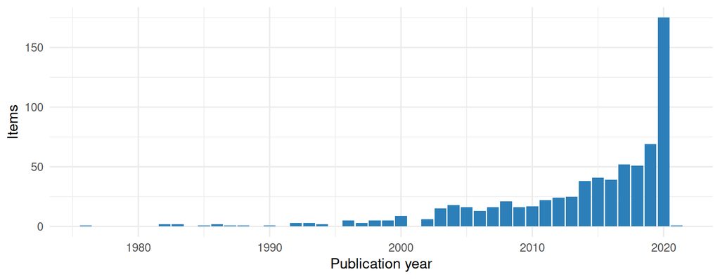

### Types of items

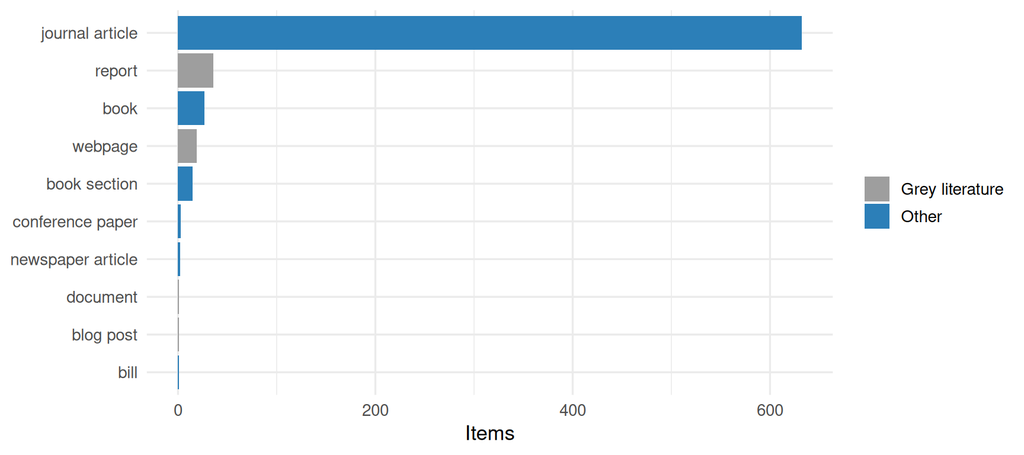

### Open access

Open access status of the publications found in OpenAlex. *Gold* and *diamond*: open in an open access journal; *hybrid*: open in a subscription journal; *green*: an open copy is in a repository; *bronze*: free to read on the publisher’s site; *closed*: not openly available.

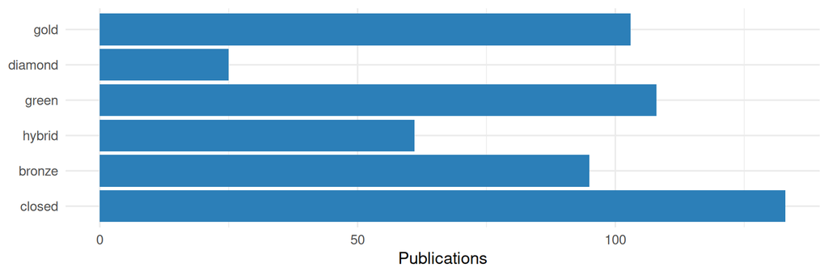

### Most frequent journals

| Journal | Items |
| --- | --- |
| Science | 36 |
| Nature | 21 |
| Proceedings of the National Academy of Sciences | 19 |
| Emerging Infectious Diseases | 18 |
| EcoHealth | 16 |
| Biological Conservation | 15 |
| The Lancet | 15 |
| Conservation Biology | 11 |
| Philosophical Transactions of the Royal Society B: Biological Sciences | 11 |
| PloS one | 9 |

### Countries of the authors

Number of publications with at least one author from the country, for the publications found in OpenAlex.

| Country | Publications |
| --- | --- |
| United States | 276 |
| United Kingdom | 160 |
| Australia | 65 |
| China | 60 |
| France | 52 |
| Germany | 43 |
| Canada | 41 |
| Brazil | 37 |
| Netherlands | 35 |
| Italy | 31 |
| Switzerland | 30 |
| Hong Kong SAR China | 22 |
| South Africa | 20 |
| Spain | 19 |
| Norway | 18 |

## How the checks work

**NoteDetails of the checks**

#### identifiers

##### DOI coverage (`met_id_doi`)

Number and share of items with a valid DOI, and items whose DOI field is filled but contains no valid DOI. DOIs are extracted with `openalexPro::extract_doi()` and lower cased.

##### ISBN coverage (`met_id_isbn`)

Number and share of items with an ISBN, overall and for the item types which should have one (`book`, `bookSection`).

##### ISSN coverage (`met_id_issn`)

Number and share of items with an ISSN, overall and for the item types which should have one (`journalArticle`, `magazineArticle`).

##### ISSN not in the standard form (`met_id_issn_form`)

Items whose ISSN field is not in the standard form: each ISSN as `1234-567X` (with hyphen, capital X), several separated by “,”. The ISSNs are checked with their check digit. If all are valid, the standard form is proposed; otherwise the item is listed with the ISSNs which are not valid.

##### DOIs in the wrong field (`met_id_doi_misplaced`)

Items with an empty DOI field but a DOI in the `Url` or `Extra` field. These DOIs are not used for the OpenAlex lookup and should be moved to the DOI field.

##### DOIs in the wrong form (`met_id_doi_form`)

Items whose DOI field contains a valid DOI, but not as a bare DOI: as a link (`https://doi.org/10.…`), with a prefix (`doi:`, `DOI`), URL-encoded (`%5B` for `[`) or with spaces or other characters around it. Citation styles add the link themselves, so a link in the DOI field appears twice in a bibliography. The bare DOI is the one recognised by `openalexPro::extract_doi()`, keeping its upper and lower case.

##### DOIs which do not exist (`met_id_doi_exists`)

Items whose DOI field contains a DOI in the right form which does not exist at doi.org: usually a typo, a shortened DOI, or a DOI with extra characters at the end (`.`, `;`, a link to supplementary material). Only DOIs which are not found in OpenAlex are checked at doi.org. Where the DOI without the extra characters at the end exists, it is given as suggestion.

##### Items without identifier (`met_id_none`)

Items with none of DOI, ISBN, ISSN or Url. These items can neither be checked against OpenAlex nor easily be retrieved by readers.

##### DOIs found in OpenAlex for items without a DOI (`met_id_candidates`)

For items without a DOI, OpenAlex was searched by title, and by the PubMed ID (line `PMID: …` in Extra), and Crossref by ISBN and title (see [get_doi_candidates()]).

#### metadata

##### Filled fields per item type (`met_meta_fields`)

Percentage of items with a filled field, per item type, for the main fields: Title, Author, Publication Year, Publication Title, Publisher, DOI, ISBN, ISSN, Url, Abstract Note and Language. Not every field is expected for every item type, e.g. reports have no Publication Title.

##### Problematic publication years (`met_meta_year`)

Items whose date is missing (`missing`), from whose date Zotero could not derive a year (`unparseable`), or whose year lies in the future (`future`).

##### Duplicate items (`met_meta_duplicates`)

Items which are in the group more than once, identified by the same DOI, or by the same normalised title (lower case, letters and digits only), publication year and first word of the first author.

##### Language not given as a standard code (`met_meta_language`)

Items whose language is not given as a standard language code, i.e. a two-letter ISO 639-1 code, optionally with a region (`en`, `en-US`), but e.g. as a name (`English`), a three-letter code (`eng`) or in a different spelling (`EN`, `en_us`). Citation styles and other tools only recognise the codes. Where the value is recognised, the standard code is proposed, based on the ISO 639-2 list (R package ISOcodes): codes, three-letter codes and the English names of the languages. Other values, e.g. names in the language itself, several languages or other text, are listed without a proposal.

#### openalex_check

##### Zotero DOIs found in OpenAlex (`met_check_found`)

Valid Zotero DOIs which were / were not found in OpenAlex. A DOI which is not found is either not indexed by OpenAlex or wrong (see `met_id_doi_exists` for DOIs which do not exist). DOIs of works which OpenAlex has under another DOI (e.g. the old and the new DOI of an article) count as found.

##### Retracted works (`met_check_retracted`)

Works flagged as retracted by OpenAlex, with the key of the Zotero item(s) with the same DOI.

##### Wrong DOIs (`met_check_mismatch`)

Items whose DOI points in OpenAlex to a work with a different title or year, which usually means that the wrong DOI is attached to the item. An item is flagged when the title similarity (normalised Levenshtein distance) is below 0.8 or the years differ by more than one. Items with the line `DOI checked: correct` in Extra (someone checked that the DOI is right, e.g. a book chapter with the DOI of the book, or a wrong year in OpenAlex) are not listed.

##### Item type agreement (`met_check_type`)

Zotero item type compared with the OpenAlex work type for items with the same DOI.

##### Missing dates found in OpenAlex (`met_check_date`)

Items without a date whose DOI was found in OpenAlex: the publication date in OpenAlex is proposed. OpenAlex gives 1 January when only the year is known, so such dates are proposed as the year only. Items whose DOI points to a different publication are left out.

##### Empty fields found in OpenAlex (`met_check_fill`)

Journal articles with an empty journal, volume, issue or pages field whose DOI was found in OpenAlex with these details: the values in OpenAlex are proposed. The journal is only taken if the publication is in a journal in OpenAlex (not e.g. a repository). Page ranges which end before they start (e.g. `1260-2`, shortened or wrong) are not proposed. Items whose DOI points to a different publication are left out.

##### Language differs from OpenAlex (`met_check_language`)

Items whose language in Zotero differs from the language of their DOI in OpenAlex. Only the language is compared, not the region (`en-US` and `en` are the same), and only for items whose language is given as a language code (see “Language not given as a language code”). Items without a language are listed under “No language”.

##### OpenAlex ID in the Extra field (`met_check_openalex_id`)

Items whose DOI was found in OpenAlex, compared with the OpenAlex ID noted in their Extra field (a line `OpenAlex: W…`). Items without such a line can get it, which links them to OpenAlex for later checks. Items with a different ID are listed for checking: OpenAlex merges records, and the ID of a merged record redirects to the new one. Items whose DOI points to a different publication are left out.

##### OpenAlex ID in the Extra field not valid (`met_check_extra_id`)

Checks the lines `OpenAlex: …` in the Extra field (looked up by [get_extra_ids()]). A line is not valid if - it is not an OpenAlex work ID (`W` and digits), - the item has several lines with different IDs, - the ID is not in OpenAlex (wrong, or merged into another record), or - the work is a different publication: its DOI is not the DOI of the item, or, for items without DOI, its title is not similar (similarity below 0.8, see [title_similarity()]).

#### profile

##### Publication years (`met_prof_year`)

Number of items per publication year, with cumulative counts. Items without a year are counted as `NA`.

##### Open access status (`met_prof_oa`)

OpenAlex open access status (gold, diamond, green, hybrid, bronze, closed) of the works, overall and per publication year.

##### Top journals (`met_prof_journals`)

The 50 most frequent journals, from the Publication Title in Zotero and the source of the primary location in OpenAlex. Ties at rank 50 are included.

##### Author countries (`met_prof_countries`)

Number of works with at least one author affiliated with an institution in a country, per country (ISO 3166-1 alpha-2 codes from OpenAlex).

##### Item types and grey literature (`met_prof_types`)

Number of items per item type (Zotero) or work type (OpenAlex), and the share of grey literature, i.e. reports, theses, dissertations, web pages, documents, presentations, manuscripts, blog posts and preprints.

##### Languages (`met_prof_language`)

Languages as entered, and normalised to two letter codes (lower case, region removed, English spellings mapped to `en`). Inconsistent codes in the language as entered are a quality issue in themselves.

#### maintenance

##### Group activity (`met_maint_activity`)

Items added per month, and items added / modified in the 30 days before the metrics were calculated.

##### Items without tags (`met_maint_tags`)

Items without manual tags. Automatic tags, e.g. keywords imported from the publisher, are ignored.

IPBES Literature Report 0.7.0 · [source code on GitHub](https://github.com/IPBES-Data/IPBES.LiteratureReport) (© IPBES.LiteratureReport authors, [MIT licence](https://opensource.org/license/mit)) · reports and data on this website: [CC0 1.0](https://creativecommons.org/publicdomain/zero/1.0/) (no rights reserved)